# Atividade 4

Ana Clara Suhett

12/05/2022

## Informações Iniciais

Essa atividade é a número 4 da disciplina de Ciência Colaborativa. Ela consiste em elaborar a presente página, utilizando os scripts que foram construídos na atividade 3.

A atividade 3 teve como objetivo utilizar dados de duas bases de dados global, o [GBIF](https://www.gbif.org/) e o [OBIS](https://obis.org/) para verificar a ocorrência de espécies, assim como algumas informações relacionadas a ela.

Aqui a espécie escolhida é o peixe recifal Pomacanthus paru, nós iremos com alguns passos elaborar três gráficos, um que contêm os dados de ocorrência do GBIF, outro com os dados de ocorrência do OBIS e por fim o último que apresenta os dois registros de ocorrência das duas plataformas.

## 1. GBIF

1.1 Instalar e carregar os pacotes necessários

```r
library(rgbif)
library(tidyverse)
library(ggmap)
library(maps)
library(mapdata)
library(dplyr)
library(robis)
```

1.2 Baixar ocorrências

1.3 Checar número de linhas, e a quantidade de colunas e nomes. Essa etapa é importante para escolhermos quais variáveis vamos incluir nos plots seguintes

```r
dim(paru_gbif)
```

```r
dim(paru_gbif$data)
```

```
## [1] 500 112
```

```r
paru_gbif$data %>% names
```

```
##   [1] "key"                              "scientificName"
##   [3] "decimalLatitude"                  "decimalLongitude"
##   [5] "issues"                           "datasetKey"
##   [7] "publishingOrgKey"                 "installationKey"
##   [9] "publishingCountry"                "protocol"
##  [11] "lastCrawled"                      "lastParsed"
##  [13] "crawlId"                          "hostingOrganizationKey"
##  [15] "basisOfRecord"                    "occurrenceStatus"
##  [17] "lifeStage"                        "taxonKey"
##  [19] "kingdomKey"                       "phylumKey"
##  [21] "classKey"                         "orderKey"
##  [23] "familyKey"                        "genusKey"
##  [25] "speciesKey"                       "acceptedTaxonKey"
##  [27] "acceptedScientificName"           "kingdom"
##  [29] "phylum"                           "order"
```

[output cut: 41 more lines]

1.4 Checar erros

```r
issues_gbif <- paru_gbif$data$issues %>%
  unique()
gbif_issues() %>%
  data.frame() %>%
  filter(code %in% issues_gbif)
```

```
##      code                                            issue
## 1 cdround                               COORDINATE_ROUNDED
## 2    cudc                 COUNTRY_DERIVED_FROM_COORDINATES
## 3   osiic OCCURRENCE_STATUS_INFERRED_FROM_INDIVIDUAL_COUNT
##                                                                                 description
## 1                                   Original coordinate modified by rounding to 5 decimals.
## 2 The interpreted country is based on the coordinates, not the verbatim string information.
## 3                            Occurrence status was inferred from the individual count value
##         type
## 1 occurrence
## 2 occurrence
## 3 occurrence
```

1.5 Checar as variáveis

```r
paru_gbif1 <- paru_gbif$data %>%
  dplyr::select(scientificName, acceptedScientificName, decimalLatitude, decimalLongitude,
                issues, waterBody, basisOfRecord, occurrenceStatus, rightsHolder,
                datasetName, recordedBy, depth, locality, habitat) %>%
  distinct()
lapply(paru_gbif1, unique)
```

```
## $scientificName
## [1] "Pomacanthus paru (Bloch, 1787)"
##
## $acceptedScientificName
## [1] "Pomacanthus paru (Bloch, 1787)"
##
## $decimalLatitude
##   [1]  20.296613  21.212282  18.365816  16.264464 -22.770536  21.212184
##   [7]  18.442172  18.472243  17.617267  13.173829  16.077986  18.514917
##  [13]  18.349672  18.509719  12.201890  18.513621  18.349492  24.548481
##  [19]  16.360623  13.866330  13.863966  12.115250  12.115305  12.114968
##  [25]  12.115052  12.092729  20.448088  12.070752  26.785482  12.198308
##  [31]  12.198164  12.210588  12.063943  12.257730  12.219072  16.898056
##  [37]  17.616975  12.115318  20.623227  26.366500  16.271874  18.081554
##  [43]  18.434045  20.813347  26.781456  18.357468  18.434584  27.026200
```

[output cut: 557 more lines]

```r
paru_gbif_ok <- paru_gbif1
```

1.6 Criando o mapa

```r
world <- map_data('world')
```

1.7 Criando dos pontos dentro do mapa

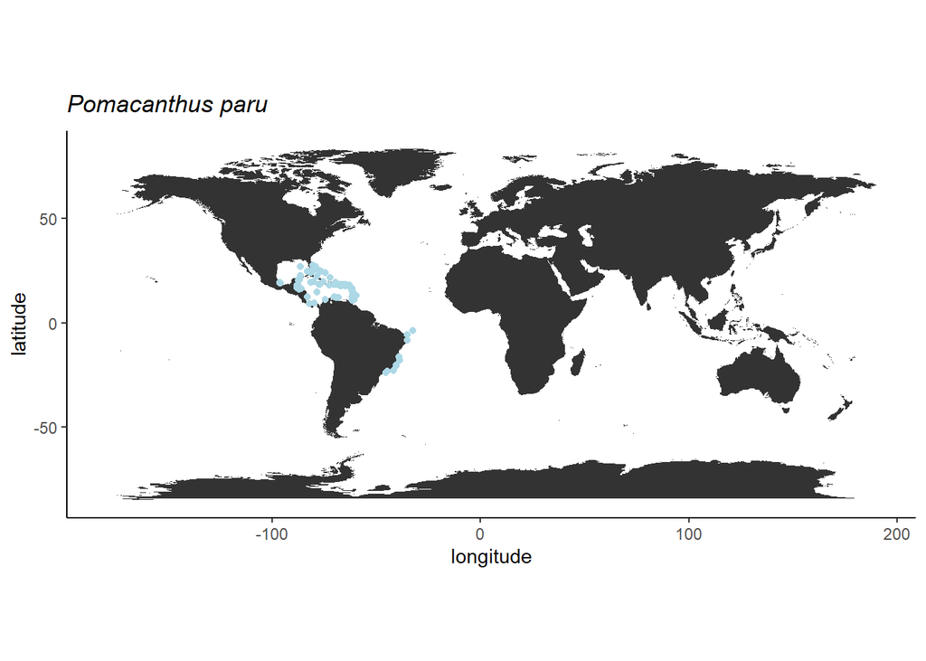

```r
ggplot() +
  geom_polygon(data = world, aes(x = long, y = lat, group = group)) +
  coord_fixed() +
  theme_classic() +
  geom_point(data = paru_gbif_ok, aes(x = decimalLongitude, y = decimalLatitude), color = "light blue") +
  labs(x = "longitude", y = "latitude", title = expression(italic("Pomacanthus paru")))
```

## 2. OBIS

2.1 Com o pacote (robis) instalado, agora vamos baixar as ocorrências e checar o nome das colunas

```
## Retrieved 5000 records of approximately 6685 (74%) Retrieved 6685 records of
## approximately 6685 (100%)
```

```
##   [1] "infraphylum"                      "country"
##   [3] "date_year"                        "habitat"
##   [5] "references"                       "scientificNameID"
##   [7] "scientificName"                   "dropped"
##   [9] "gigaclassid"                      "aphiaID"
##  [11] "language"                         "decimalLatitude"
##  [13] "subclassid"                       "type"
##  [15] "gigaclass"                        "infraphylumid"
##  [17] "phylumid"                         "familyid"
##  [19] "occurrenceStatus"                 "basisOfRecord"
##  [21] "terrestrial"                      "modified"
##  [23] "maximumDepthInMeters"             "id"
##  [25] "parvphylum"                       "order"
##  [27] "dataset_id"                       "minimumElevationInMeters"
##  [29] "stateProvince"                    "decimalLongitude"
```

[output cut: 62 more lines]

2.2 Selecionar collunas de registros únicos

```r
paru_obis1 <- paru_obis %>%
  dplyr::select(scientificName, decimalLatitude, decimalLongitude, bathymetry,
                flags, waterBody, basisOfRecord, occurrenceStatus, rightsHolder,
                datasetName, recordedBy, depth, locality, habitat) %>%
  distinct()
```

2.3 Checar problemas reportados (flags)

```r
paru_obis1 %>%
  distinct(flags)
```

```
## # A tibble: 6 x 1
##   flags
##   <chr>
## 1 <NA>
## 2 NO_DEPTH
## 3 NO_DEPTH,ON_LAND
## 4 ON_LAND,DEPTH_EXCEEDS_BATH
## 5 ON_LAND
## 6 DEPTH_EXCEEDS_BATH
```

```r
paru_obis1 %>%
  filter(!flags %in% c("on_land,no_depth","no_depth,on_land", "on_land", "on_land,depth_exceeds_bath", "depth_exceeds_bath,on_land"),
         !is.na(datasetName)) %>%
  lapply(., unique)
```

```
## $scientificName
## [1] "Pomacanthus paru"
##
## $decimalLatitude
##    [1]  25.037767  24.673130  24.678233  24.710450  25.513567  24.456660
##    [7]  24.783167  24.567350  25.712800  25.138920  24.566333  25.198750
##   [13]  25.385590  24.700820  24.804400  24.658733  17.934980  25.030867
##   [19]  24.572440  25.032000  25.042917  24.869600  24.477750  24.698617
##   [25]  24.468067  24.907680  24.674220  11.329861  24.600550  24.613000
##   [31]  25.374417  17.956320  24.610633  25.098617  24.566917  24.667040
##   [37]  24.765500  25.431367  25.462000  24.852170   8.662139  18.461180
##   [43]  24.570317  24.648400  24.476100  25.560617  24.436000  24.636340
##   [49]  24.546830  24.544283  25.397880  24.707540  24.567050  25.702500
##   [55]  25.495733  25.033000  25.569370  24.990200  24.529000  25.332983
##   [61]  24.688300  25.305580  18.346520  24.935620  24.905417  18.337970
```

[output cut: 1334 more lines]

```r
paru_obis_ok <- paru_obis1 %>%
  dplyr::filter(!flags %in% c("on_land,no_depth","no_depth,on_land", "on_land", "on_land,depth_exceeds_bath", "depth_exceeds_bath,on_land"),
         !is.na(datasetName))
```

2.5 Agora vamos gerar o mapa com os dados do OBIS

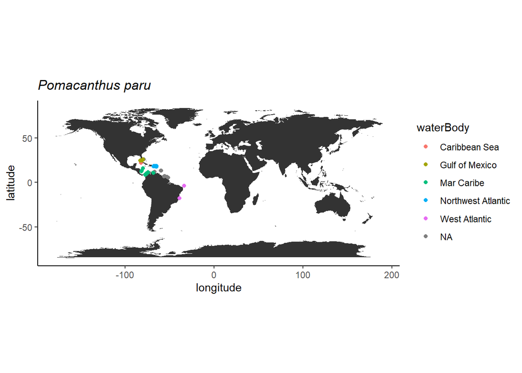

```r
ggplot() +
  geom_polygon(data = world, aes(x = long, y = lat, group = group)) +
  coord_fixed() +
  theme_classic() +
  geom_point(data = paru_obis_ok, aes(x = decimalLongitude, y = decimalLatitude, color = waterBody)) +
  labs(x = "longitude", y = "latitude", title = expression(italic("Pomacanthus paru")))
```

## 3. Unindo os dados do GBIF e OBIS

```r
all_data <- bind_rows(paru_gbif_ok %>%
                        mutate(repo = paste0("gbif", row.names(.))),
                      paru_obis_ok %>%
                        mutate(repo = paste0("obis", row.names(.)))) %>%
  column_to_rownames("repo") %>%
  dplyr::select(decimalLongitude, decimalLatitude, depth) %>%
  distinct() %>%
  rownames_to_column("occ") %>%
  separate(col = "occ", into = c("datasetName", "rn"), sep = 4) %>%
  mutate(scientificName = "Pomacanthus paru") %>%
  dplyr::select(-rn)
```

3.1 Criando o mapa com todas as ocorrências

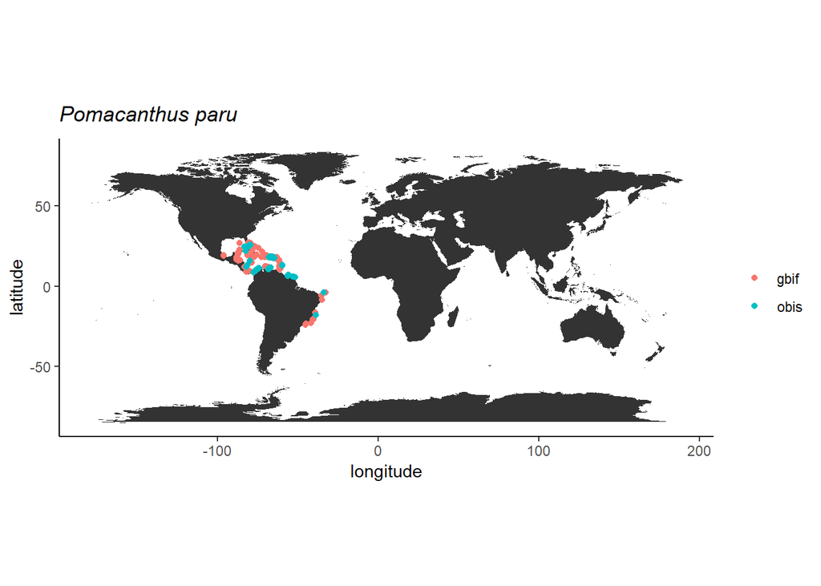

```r
ggplot() +
  geom_polygon(data = world, aes(x = long, y = lat, group = group)) +
  coord_fixed() +
  theme_classic() +
  geom_point(data = all_data, aes(x = decimalLongitude, y = decimalLatitude, color = datasetName)) +
  theme(legend.title = element_blank()) +
  labs(x = "longitude", y = "latitude", title = expression(italic("Pomacanthus paru")))
```

```r
write.csv(all_data, "occ-GBIF-OBIS.csv", row.names = FALSE)
```